# EarthquakeVignette

James Frech

7/12/2021

This package contains nine new functions, two new geoms, and a dataset used to work with data observed from earthquakes. Examples are below.

Dataset) EarthquakeData: if you don’t have your own data to read in or don’t want to gather it, I have included the full dataset from NOAA as part of this package for use. This dataset has quite a few NA’s, especially for older earthquakes. As a result, there tend to be quite a few warnings, or points removed from graphs if the values are NA.

Function 1) read_earthquake_data: used to read in a dataset of earthquake data in tsv format. This function will work with any dataset you created while searching the NOAA Significant Earthquake Database. This database is found here: https://www.ncei.noaa.gov/access/metadata/landing-page/bin/iso?id=gov.noaa.ngdc.mgg.hazards:G012153

Function 2) replace_NA: This function replaces the NA’s in a column of a dataframe or any vector.

Function 3) eq_clean_data: This function creates a Date column out of the year, month, and day columns and turns the Latitude and Longitude columns into the numeric class.

Function 4) eq_location_clean: This function removes the country from the Location Name column and turns Country into its own column.

Function 5) geom_timeline: This function adds the new timeline geom to your ggplot.

Function 6) geom_timelinelabel: Creates labels for specific points of your timeline by using the new timelinelabel geom.

Function 7) n_max: This function allows you to choose the max amount of labels you want on your timeline.

Function 8) eq_map: Creates a map widget that maps earthquake epicenters.

Function 9) eq_create_label: This function creates a label for your earthquake epicenters that tell you the location, Magnitude, and Total Deaths

```r
# Function 1
read_earthquake_data <- function(file){
  data <- readr::read_tsv(file)
  return(data)
}

# Function 2
replace_NA <- function(df, value){
  for(i in seq_along(df)){
    if(is.na(df[i])){
      df[i] <- value
    }
  }
  return(df)
}

# Function 3
eq_clean_data <- function(df){
  df <- df[2:6243,] %>%
    # replace NA's in date and time with 01 for day and month and 0 for hour, minutes, and seconds
    dplyr::mutate(Mo = replace_NA(.$Mo, 01), Dy = replace_NA(.$Dy, 01), Hr = replace_NA(.$Hr, 0),
                  Mn = replace_NA(.$Mn, 0), Sec = replace_NA(.$Sec, 0)) %>%
    # add in 3000 years since the ymd function can only work with dates over the year 1000
    dplyr::mutate(Year = .$Year+3152) %>%
    dplyr::select(!"Search Parameters") %>%
    # create date column from the separate year, month, and date columns
    tidyr::unite(Date, Year, Mo, Dy, sep ="-") %>%
    dplyr::mutate(Date = lubridate::ymd(.$Date)) %>%
    # subtract the amount of days necessary to get the years back to the right time.
    dplyr::mutate(Date = .$Date-1151244) %>%
    dplyr::mutate(Latitude = as.numeric(.$Latitude), Longitude = as.numeric(.$Longitude))
  return(df)
}

# Function 4
eq_location_clean <- function(df, j){
  column <- as.data.frame(df[,j])
  country <- rep(0, nrow(df))
  for(i in 1:nrow(column)){
    if(grepl(":", column[i,])){
      country[i] <- stringr::str_extract(column[i,], "^[^:]+")
      column[i,] <- stringr::str_extract(column[i,], "[^:]+$")
      column[i,] <- stringr::str_trim(column[i,], side = "left")
    }
    else{
      country[i] <- column[i,]
    }
    column[i,] <- stringr::str_to_title(column[i,])
  }
  for(i in 1:nrow(column)){
    if((any(state.name %in% column[i,]) | any(toupper(state.name) %in% country[i])) &
       ((df$Longitude[i] < 40) | is.na(df$Longitude[i]))){
      country[i] <- "USA"
    }
  }
  df[,j] <- column
  df <- dplyr::mutate(df, Country = stringr::str_to_title(country))
  return(df)
}

# Geom for function 5
GeomTimeline <- ggplot2::ggproto("GeomTimeline", ggplot2::Geom,
                                 required_aes = c("x", "y"),
                                 default_aes = ggplot2::aes(color = "black", size = 1,
                                                            alpha = 1, shape = 16),
                                 draw_key = ggplot2::draw_key_point,
                                 draw_panel = function(data, panel_scales, coord){
                                   coords <- ggplot2::coord_munch(coord, data, panel_scales)
                                   coords <- na.omit(coords)
                                   grid::pointsGrob(
                                     x = coords$x,
                                     y = coords$y,
                                     size = grid::unit(coords$size*.5, "char"),
                                     pch = coords$shape,
                                     gp = grid::gpar(col = coords$col, alpha = coords$alpha)
                                   )
                                 })

# Function 5
geom_timeline <- function(mapping = NULL, data = NULL, stat = "identity", position = "identity",
                          na.rm = FALSE, show.legend = NA, inherit.aes = TRUE, ...){
  ggplot2::layer(
    geom = GeomTimeline, mapping = mapping, data = data, stat = stat, position = position,
    show.legend = show.legend, inherit.aes = inherit.aes, params = list(na.rm = na.rm, ...)
  )
}

# Geom for function 6
GeomTimelineLabel <- ggplot2::ggproto("GeomTimelineLabel", ggplot2::Geom,
                                      required_aes = c("x", "y", "label"),
                                      default_aes = ggplot2::aes(color = "grey", alpha = .75),
                                      draw_key = ggplot2::draw_key_vline,
                                      draw_panel = function(data, panel_scales, coord){
                                        coords <- ggplot2::coord_munch(coord, data, panel_scales)
                                        coords <- na.omit(coords)
                                        Line <- grid::segmentsGrob(
                                          x0 = coords$x,
                                          x1 = coords$x,
                                          y0 = coords$y,
                                          y1 = coords$y + .05,
                                          gp = grid::gpar(col = coords$col, alpha = coords$alpha)
                                        )
                                        Text <- grid::textGrob(
                                          x = coords$x,
                                          y = coords$y + .1,
                                          label = coords$label,
                                          rot = 40
                                        )
                                        grid::gTree(children = grid::gList(Line, Text))
                                      }
)

# Function 6
geom_timelinelabel <- function(mapping = NULL, data = NULL, stat = "identity", position = "identity",
                               na.rm = FALSE, show.legend = NA, inherit.aes = TRUE, ...){
  ggplot2::layer(
    geom = GeomTimelineLabel, mapping = mapping, data = data, stat = stat, position = position,
    show.legend = show.legend, inherit.aes = inherit.aes, params = list(na.rm = na.rm, ...)
  )
}

# Function 7
n_max <- function(df, column, n, desc = TRUE){
  if(desc == TRUE){
    df <- df %>%
      dplyr::arrange(desc(df[,column])) %>%
      head(n)
  }
  else{
    df <- df %>%
      dplyr::arrange(df[,column]) %>%
      head(n)
  }
  return(df)
}

# function 8
eq_map <- function(df, annot_col, color = "blue", radius = 5, weight = 1){
  leaflet::leaflet() %>%
    leaflet::addTiles() %>%
    leaflet::addCircleMarkers(data = df, lat = ~ Latitude, lng = ~ Longitude, radius = radius,
                              popup = paste0(annot_col), color = color, weight = weight)
}

# function 9
eq_create_label <- function(df){
  label <- paste("<b>Location:</b>", df$`Location Name`, "<br />",
                 "<b>Magnitude:</b>", df$Mag, "<br />",
                 "<b>Total Deaths:</b>", df$`Total Deaths`, "<br />")
  return(label)
}

library(readr)
library(dplyr)
library(tidyr)
library(lubridate)
library(stringr)
library(roxygen2)
library(ggplot2)
library(grid)
library(leaflet)
# read_earthquake_data example
EarthquakeData <- read_earthquake_data("NOAASignificantEarthquakes.tsv")
print(EarthquakeData)
```

```
## # A tibble: 6,243 x 39
##    `Search Paramet~  Year    Mo    Dy    Hr    Mn   Sec   Tsu   Vol
##    <chr>            <dbl> <dbl> <dbl> <dbl> <dbl> <dbl> <dbl> <dbl>
##  1 []                  NA    NA    NA    NA    NA    NA    NA    NA
##  2 <NA>             -2150    NA    NA    NA    NA     0    NA    NA
##  3 <NA>             -2000    NA    NA    NA    NA    NA     1    NA
##  4 <NA>             -2000    NA    NA    NA    NA    NA    NA    NA
##  5 <NA>             -1610    NA    NA    NA    NA    NA     3  1351
##  6 <NA>             -1566    NA    NA    NA    NA     0    NA    NA
##  7 <NA>             -1450    NA    NA    NA    NA    NA    NA    NA
##  8 <NA>             -1365    NA    NA    NA    NA    NA     4    NA
##  9 <NA>             -1250    NA    NA    NA    NA     0    NA    NA
## 10 <NA>             -1050    NA    NA    NA    NA     0    NA    NA
## # ... with 6,233 more rows, and 30 more variables: `Location Name` <chr>,
## #   Latitude <dbl>, Longitude <dbl>, `Focal Depth (km)` <dbl>, Mag <dbl>, `MMI
## #   Int` <dbl>, Deaths <dbl>, `Death Description` <dbl>, Missing <lgl>,
## #   `Missing Description` <dbl>, Injuries <dbl>, `Injuries Description` <dbl>,
## #   `Damage ($Mil)` <lgl>, `Damage Description` <dbl>, `Houses
## #   Destroyed` <dbl>, `Houses Destroyed Description` <dbl>, `Houses
## #   Damaged` <dbl>, `Houses Damaged Description` <dbl>, `Total Deaths` <dbl>,
## #   `Total Death Description` <dbl>, `Total Missing` <lgl>, `Total Missing
## #   Description` <lgl>, `Total Injuries` <dbl>, `Total Injuries
## #   Description` <dbl>, `Total Damage ($Mil)` <lgl>, `Total Damage
## #   Description` <dbl>, `Total Houses Destroyed` <dbl>, `Total Houses Destroyed
## #   Description` <dbl>, `Total Houses Damaged` <dbl>, `Total Houses Damaged
## #   Description` <dbl>
```

```r
# replace_NA example
print(EarthquakeData$Mo[1:25])
```

```
##  [1] NA NA NA NA NA NA NA NA NA NA NA NA NA NA  9 NA NA  6 NA NA NA NA 11 NA NA
```

```r
replace_NA(EarthquakeData$Mo[1:25], 01)
```

```
##  [1]  1  1  1  1  1  1  1  1  1  1  1  1  1  1  9  1  1  6  1  1  1  1 11  1  1
```

```r
# eq_clean_data example
eq_clean_data(EarthquakeData)
```

```
## # A tibble: 6,242 x 36
##    Date          Hr    Mn   Sec   Tsu   Vol `Location Name` Latitude Longitude
##    <date>     <dbl> <dbl> <dbl> <dbl> <dbl> <chr>              <dbl>     <dbl>
##  1 -2150-01-01     0     0     0    NA    NA JORDAN:  BAB-A~     31.1      35.5
##  2 -2000-01-01     0     0     0     1    NA SYRIA:  UGARIT      35.7      35.8
##  3 -2000-01-01     0     0     0    NA    NA TURKMENISTAN: ~     38        58.2
##  4 -1610-01-01     0     0     0     3  1351 GREECE:  THERA~     36.4      25.4
##  5 -1566-01-01     0     0     0    NA    NA ISRAEL:  ARIHA~     31.5      35.3
##  6 -1450-01-01     0     0     0    NA    NA ITALY:  LACUS ~     35.5      25.5
##  7 -1365-01-02     0     0     0     4    NA SYRIAN COASTS       35.7      35.8
##  8 -1250-01-01     0     0     0    NA    NA ISRAEL:  ARIHA~     32        35.5
##  9 -1050-01-01     0     0     0    NA    NA JORDAN:  SW:  ~     29.6      35
## 10 -759-01-01     0     0     0    NA    NA ISRAEL:  JERUS~     33        35.5
## # ... with 6,232 more rows, and 27 more variables: `Focal Depth (km)` <dbl>,
## #   Mag <dbl>, `MMI Int` <dbl>, Deaths <dbl>, `Death Description` <dbl>,
## #   Missing <lgl>, `Missing Description` <dbl>, Injuries <dbl>, `Injuries
## #   Description` <dbl>, `Damage ($Mil)` <lgl>, `Damage Description` <dbl>,
## #   `Houses Destroyed` <dbl>, `Houses Destroyed Description` <dbl>, `Houses
## #   Damaged` <dbl>, `Houses Damaged Description` <dbl>, `Total Deaths` <dbl>,
## #   `Total Death Description` <dbl>, `Total Missing` <lgl>, `Total Missing
## #   Description` <lgl>, `Total Injuries` <dbl>, `Total Injuries
## #   Description` <dbl>, `Total Damage ($Mil)` <lgl>, `Total Damage
## #   Description` <dbl>, `Total Houses Destroyed` <dbl>, `Total Houses Destroyed
## #   Description` <dbl>, `Total Houses Damaged` <dbl>, `Total Houses Damaged
## #   Description` <dbl>
```

```r
# eq_location_clean example
EarthquakeData %>%
  eq_clean_data() %>%
  eq_location_clean(7)
```

```
## # A tibble: 6,242 x 37
##    Date          Hr    Mn   Sec   Tsu   Vol `Location Name` Latitude Longitude
##    <date>     <dbl> <dbl> <dbl> <dbl> <dbl> <chr>              <dbl>     <dbl>
##  1 -2150-01-01     0     0     0    NA    NA Bab-A-Daraa,Al~     31.1      35.5
##  2 -2000-01-01     0     0     0     1    NA Ugarit              35.7      35.8
##  3 -2000-01-01     0     0     0    NA    NA W                   38        58.2
##  4 -1610-01-01     0     0     0     3  1351 Thera Island (~     36.4      25.4
##  5 -1566-01-01     0     0     0    NA    NA Ariha (Jericho)     31.5      35.3
##  6 -1450-01-01     0     0     0    NA    NA Lacus Cimini        35.5      25.5
##  7 -1365-01-02     0     0     0     4    NA Syrian Coasts       35.7      35.8
##  8 -1250-01-01     0     0     0    NA    NA Ariha (Jericho)     32        35.5
##  9 -1050-01-01     0     0     0    NA    NA Timna Copper M~     29.6      35
## 10 -759-01-01     0     0     0    NA    NA Jerusalem           33        35.5
## # ... with 6,232 more rows, and 28 more variables: `Focal Depth (km)` <dbl>,
## #   Mag <dbl>, `MMI Int` <dbl>, Deaths <dbl>, `Death Description` <dbl>,
## #   Missing <lgl>, `Missing Description` <dbl>, Injuries <dbl>, `Injuries
## #   Description` <dbl>, `Damage ($Mil)` <lgl>, `Damage Description` <dbl>,
## #   `Houses Destroyed` <dbl>, `Houses Destroyed Description` <dbl>, `Houses
## #   Damaged` <dbl>, `Houses Damaged Description` <dbl>, `Total Deaths` <dbl>,
## #   `Total Death Description` <dbl>, `Total Missing` <lgl>, `Total Missing
## #   Description` <lgl>, `Total Injuries` <dbl>, `Total Injuries
## #   Description` <dbl>, `Total Damage ($Mil)` <lgl>, `Total Damage
## #   Description` <dbl>, `Total Houses Destroyed` <dbl>, `Total Houses Destroyed
## #   Description` <dbl>, `Total Houses Damaged` <dbl>, `Total Houses Damaged
## #   Description` <dbl>, Country <chr>
```

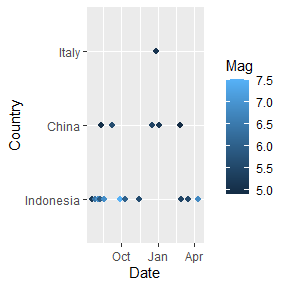

```r
# geom_timeline example
EarthquakeData[6100:6150,] %>%
  eq_clean_data() %>%
  eq_location_clean(7) %>%
  filter(Country %in% c("Italy", "Indonesia", "China")) %>%
  ggplot(aes(x = Date, y = factor(Country, levels = unique(Country)))) +
  geom_timeline(aes(color = Mag)) +
  ylab("Country")
```

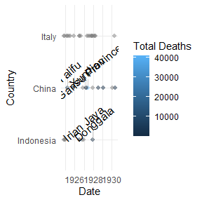

```r
# geom_timelinelabel and n_max example
Earthquake3000 <- EarthquakeData[3000:3150,] %>%
  eq_clean_data() %>%
  eq_location_clean(7) %>%
  filter(Country %in% c("Italy", "Indonesia", "China")) %>%
  arrange(desc(Mag))
ggplot(data = Earthquake3000) +
  geom_timeline(aes(x = Date, y = factor(Country, levels = unique(Country)), color = `Total Deaths`), alpha = 0.5) +
  geom_timelinelabel(data = n_max(Earthquake3000, 15, 5),
                     aes(x = Date, y = factor(Country, levels = unique(Country)), label = `Location Name`)) +
  ylab("Country") +
  theme_minimal()
```

```r
# eq_map example
EarthquakeData %>%
  eq_clean_data() %>%
  eq_location_clean(7) %>%
  filter(Country == "Mexico" & year(Date) >= 2000) %>%
  eq_map(annot_col = .$Date)
```

[interactive chart not shown]

```r
# eq_create_label example
EarthquakeData %>%
  eq_clean_data() %>%
  eq_location_clean(7) %>%
  filter(Country == "Italy" & year(Date) >= 2000) %>%
  mutate(popup_label = eq_create_label(.)) %>%
  eq_map(annot_col = .$popup_label, radius = 7, weight = 1)
```

[interactive chart not shown]